# Reproducible Research: Peer Assessment 1

## Question 1: Loading and preprocessing the data

We load the activity data from csv into dataframe activity0. The original data contains 17568 observations which is partially missing in variable steps.

```r
activity0 <- read.csv("activity.csv")
str(activity0) # 17568 observations
```

```
## 'data.frame':    17568 obs. of  3 variables:
##  $ steps   : int  NA NA NA NA NA NA NA NA NA NA ...
##  $ date    : Factor w/ 61 levels "2012-10-01","2012-10-02",..: 1 1 1 1 1 1 1 1 1 1 ...
##  $ interval: int  0 5 10 15 20 25 30 35 40 45 ...
```

We remove the rows with missing data and obtain data frame activity.

```r
wd  <- complete.cases(activity0)
activity = activity0[wd,] # 15264 left
str(activity)
```

```
## 'data.frame':    15264 obs. of  3 variables:
##  $ steps   : int  0 0 0 0 0 0 0 0 0 0 ...
##  $ date    : Factor w/ 61 levels "2012-10-01","2012-10-02",..: 2 2 2 2 2 2 2 2 2 2 ...
##  $ interval: int  0 5 10 15 20 25 30 35 40 45 ...
```

## Question 2: What is mean total number of steps taken per day?

We use library dplyr to calculate the total number of steps per day.

```r
library(dplyr)
resQ2 <- activity %>%
  group_by(date) %>%
  summarize(totalsteps = sum(steps,na.rm=TRUE))
```

The mean and median are

```r
mean(resQ2$totalsteps)
```

```
## [1] 10766.19
```

```r
median(resQ2$totalsteps)
```

```
## [1] 10765
```

Use library ggplot2 to create a histogram

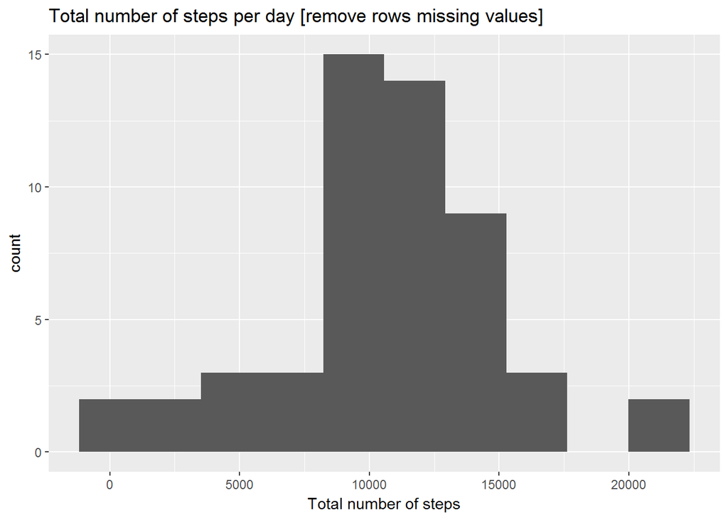

```r
library(ggplot2)
qplot(totalsteps,data = resQ2,bins = 10,xlab = "Total number of steps",main = "Total number of steps per day [remove rows missing values]")
```

## Question 3: What is the average daily activity pattern?

Calculate the average number of steps taken averaged across all days in the dataset.

```r
resQ3 <- activity %>%
  group_by(interval) %>%
  summarize(avsteps = mean(steps,na.rm=TRUE))
```

We find the maximum number of steps is on average made on interval 8:35

```r
maxsteps <- which.max(resQ3$avsteps)
resQ3$interval[maxsteps]
```

```
## [1] 835
```

This brings the following lineplot

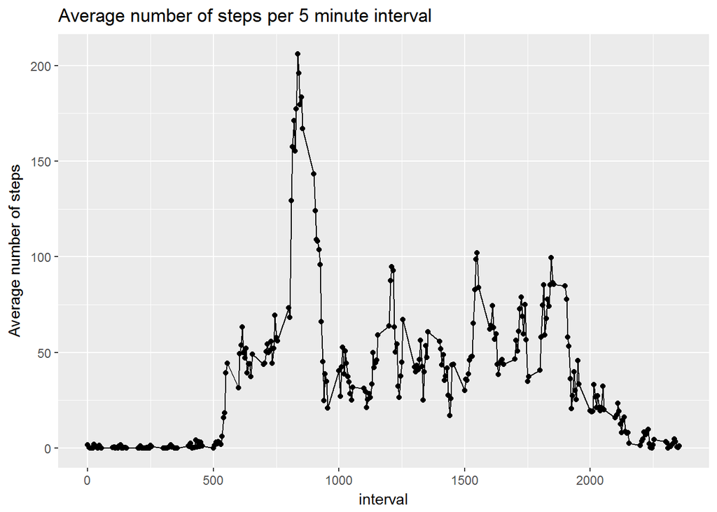

```r
qplot(interval,avsteps, data = resQ3, ylab= "Average number of steps", main = "Average number of steps per 5 minute interval") + geom_line()
```

## Question 4: Imputing missing values

There were missing data in the original dataset.

```r
wd  <- complete.cases(activity0)
sum(!wd) # 2304 rows with NA
```

```
## [1] 2304
```

Above we took out the rows with missing values. Here we impute values. We recognize that we cannot add mean/median from that specific day as there are days which are completely NA. Thus we replace missing values with the mean for the 5 minute interval. Create dataframe activity_ext which picks the original number of steps when it is available, and otherwise the mean value.

```r
activity_ext <- merge(activity0,resQ3,by.x="interval",by.y="interval")
activity_ext$steps2 = ifelse (is.na(activity_ext$steps), activity_ext$avsteps,activity_ext$steps)
```

And derive the total number of steps per day

```r
resQ4 <- activity_ext %>%
  group_by(date) %>%
  summarize(totalsteps = sum(steps2,na.rm=TRUE))
```

The mean and median have hardly changed from the above situation where we removed the rows

```r
mean(resQ4$totalsteps)
```

```
## [1] 10766.19
```

```r
median(resQ4$totalsteps)
```

```
## [1] 10766.19
```

The histogram becomes

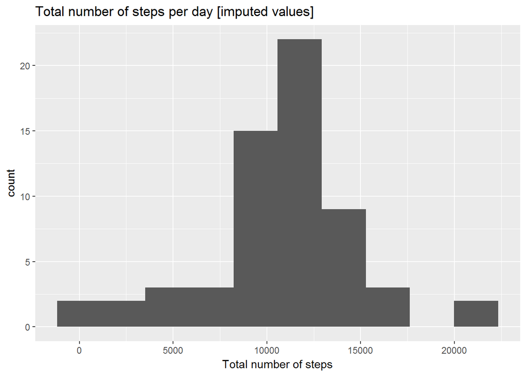

```r
qplot(totalsteps,data = resQ4,bins = 10,xlab = "Total number of steps",main = "Total number of steps per day [imputed values]")
```

Thus we conclude the impact of imputing missing data versus deleting the rows is limited.

## Q5 Are there differences in activity patterns between weekdays and weekends?

Add a new factor variable to our dataframe indicating whether it was weekday or weekend

```r
library(lubridate)
activity_ext$date = ymd(activity_ext$date) # make a date object

activity_ext$weekday = wday(activity_ext$date)
indWeekend = (activity_ext$weekday== 7 |  activity_ext$weekday== 1)
activity_ext$week_weekend[indWeekend] = "weekend"
activity_ext$week_weekend[!indWeekend] = "week"
activity_ext$week_weekend =as.factor(activity_ext$week_weekend)
```

Create panel plot with the average number of steps

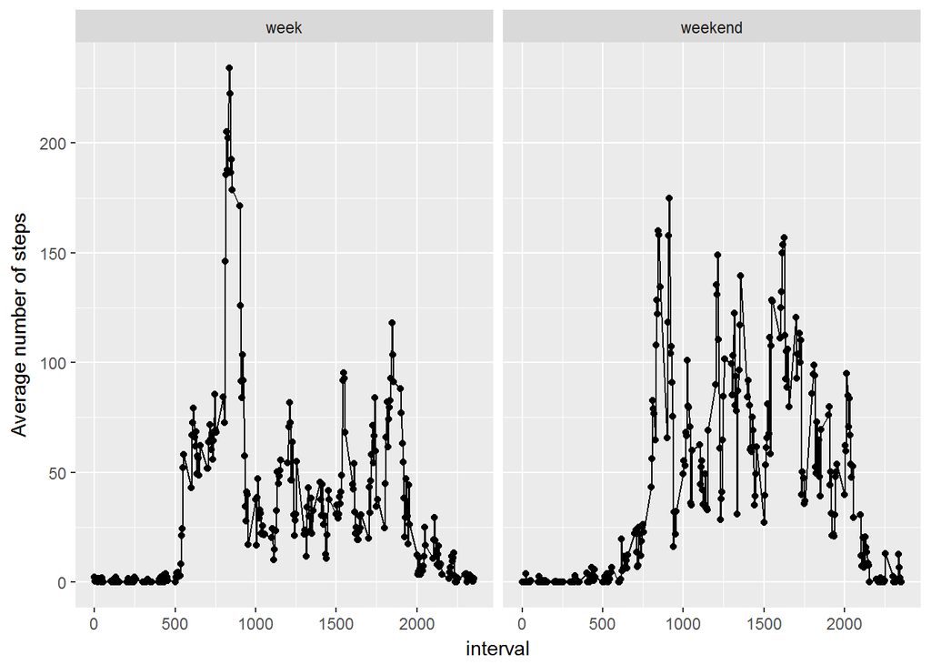

```r
resQ5 <- activity_ext %>%
  group_by(interval,week_weekend) %>%
  summarize(avsteps = mean(steps,na.rm=TRUE))

qplot(interval,avsteps, data = resQ5,facets = .~week_weekend, ylab= "Average number of steps") + geom_line()
```